# Risk Factor Analysis

## Outcome Variable

**Outcome Variable:** wasted

## Predictor Variables

**Intervention Variable:** hfoodsec

**Adjustment Set:**

- arm
- sex
- W_mage
- meducyrs
- feducyrs
- hhwealth_quart
- vagbrth
- W_nrooms
- W_nchldlt5
- brthmon
- W_parity
- impfloor
- impsan
- safeh20
- delta_W_mage
- delta_meducyrs
- delta_feducyrs
- delta_hhwealth_quart
- delta_vagbrth
- delta_W_nrooms
- delta_W_nchldlt5
- delta_brthmon
- delta_W_parity
- delta_impfloor
- delta_impsan
- delta_safeh20

## Stratifying Variables

The analysis was stratified on these variable(s):

- agecat
- studyid
- country

## Data Summary

| agecat | studyid | country | hfoodsec | wasted | n_cell | n |
| --- | --- | --- | --- | --- | --- | --- |
| Birth | ki0047075b-MAL-ED | BANGLADESH | Food Secure | 0 | 113 | 162 |
| Birth | ki0047075b-MAL-ED | BANGLADESH | Food Secure | 1 | 25 | 162 |
| Birth | ki0047075b-MAL-ED | BANGLADESH | Mildly Food Insecure | 0 | 3 | 162 |
| Birth | ki0047075b-MAL-ED | BANGLADESH | Mildly Food Insecure | 1 | 0 | 162 |
| Birth | ki0047075b-MAL-ED | BANGLADESH | Food Insecure | 0 | 17 | 162 |
| Birth | ki0047075b-MAL-ED | BANGLADESH | Food Insecure | 1 | 4 | 162 |
| Birth | ki0047075b-MAL-ED | BRAZIL | Food Secure | 0 | 0 | 26 |
| Birth | ki0047075b-MAL-ED | BRAZIL | Food Secure | 1 | 0 | 26 |
| Birth | ki0047075b-MAL-ED | BRAZIL | Mildly Food Insecure | 0 | 4 | 26 |
| Birth | ki0047075b-MAL-ED | BRAZIL | Mildly Food Insecure | 1 | 0 | 26 |
| Birth | ki0047075b-MAL-ED | BRAZIL | Food Insecure | 0 | 21 | 26 |
| Birth | ki0047075b-MAL-ED | BRAZIL | Food Insecure | 1 | 1 | 26 |
| Birth | ki0047075b-MAL-ED | INDIA | Food Secure | 0 | 29 | 35 |
| Birth | ki0047075b-MAL-ED | INDIA | Food Secure | 1 | 3 | 35 |
| Birth | ki0047075b-MAL-ED | INDIA | Mildly Food Insecure | 0 | 1 | 35 |
| Birth | ki0047075b-MAL-ED | INDIA | Mildly Food Insecure | 1 | 0 | 35 |
| Birth | ki0047075b-MAL-ED | INDIA | Food Insecure | 0 | 0 | 35 |
| Birth | ki0047075b-MAL-ED | INDIA | Food Insecure | 1 | 2 | 35 |
| Birth | ki0047075b-MAL-ED | NEPAL | Food Secure | 0 | 10 | 14 |
| Birth | ki0047075b-MAL-ED | NEPAL | Food Secure | 1 | 0 | 14 |
| Birth | ki0047075b-MAL-ED | NEPAL | Mildly Food Insecure | 0 | 1 | 14 |
| Birth | ki0047075b-MAL-ED | NEPAL | Mildly Food Insecure | 1 | 0 | 14 |
| Birth | ki0047075b-MAL-ED | NEPAL | Food Insecure | 0 | 2 | 14 |
| Birth | ki0047075b-MAL-ED | NEPAL | Food Insecure | 1 | 1 | 14 |
| Birth | ki0047075b-MAL-ED | PERU | Food Secure | 0 | 22 | 89 |
| Birth | ki0047075b-MAL-ED | PERU | Food Secure | 1 | 1 | 89 |
| Birth | ki0047075b-MAL-ED | PERU | Mildly Food Insecure | 0 | 22 | 89 |
| Birth | ki0047075b-MAL-ED | PERU | Mildly Food Insecure | 1 | 0 | 89 |
| Birth | ki0047075b-MAL-ED | PERU | Food Insecure | 0 | 42 | 89 |
| Birth | ki0047075b-MAL-ED | PERU | Food Insecure | 1 | 2 | 89 |

[output cut: 168 more lines]

The following strata were considered:

- agecat: 24 months, studyid: ki0047075b-MAL-ED, country: BANGLADESH
- agecat: 24 months, studyid: ki0047075b-MAL-ED, country: BRAZIL
- agecat: 24 months, studyid: ki0047075b-MAL-ED, country: INDIA
- agecat: 24 months, studyid: ki0047075b-MAL-ED, country: NEPAL
- agecat: 24 months, studyid: ki0047075b-MAL-ED, country: PERU
- agecat: 24 months, studyid: ki0047075b-MAL-ED, country: SOUTH AFRICA
- agecat: 24 months, studyid: ki1017093-NIH-Birth, country: BANGLADESH
- agecat: 24 months, studyid: ki1017093c-NIH-Crypto, country: BANGLADESH
- agecat: 24 months, studyid: ki1113344-GMS-Nepal, country: NEPAL
- agecat: 24 months, studyid: kiGH5241-JiVitA-3, country: BANGLADESH
- agecat: 24 months, studyid: kiGH5241-JiVitA-4, country: BANGLADESH
- agecat: 6 months, studyid: ki0047075b-MAL-ED, country: BANGLADESH
- agecat: 6 months, studyid: ki0047075b-MAL-ED, country: BRAZIL
- agecat: 6 months, studyid: ki0047075b-MAL-ED, country: INDIA
- agecat: 6 months, studyid: ki0047075b-MAL-ED, country: NEPAL
- agecat: 6 months, studyid: ki0047075b-MAL-ED, country: PERU
- agecat: 6 months, studyid: ki0047075b-MAL-ED, country: SOUTH AFRICA
- agecat: 6 months, studyid: ki1017093-NIH-Birth, country: BANGLADESH
- agecat: 6 months, studyid: ki1017093c-NIH-Crypto, country: BANGLADESH
- agecat: 6 months, studyid: ki1113344-GMS-Nepal, country: NEPAL
- agecat: 6 months, studyid: kiGH5241-JiVitA-3, country: BANGLADESH
- agecat: 6 months, studyid: kiGH5241-JiVitA-4, country: BANGLADESH
- agecat: Birth, studyid: ki0047075b-MAL-ED, country: BANGLADESH
- agecat: Birth, studyid: ki0047075b-MAL-ED, country: BRAZIL
- agecat: Birth, studyid: ki0047075b-MAL-ED, country: INDIA
- agecat: Birth, studyid: ki0047075b-MAL-ED, country: NEPAL
- agecat: Birth, studyid: ki0047075b-MAL-ED, country: PERU
- agecat: Birth, studyid: ki0047075b-MAL-ED, country: SOUTH AFRICA
- agecat: Birth, studyid: ki1017093-NIH-Birth, country: BANGLADESH
- agecat: Birth, studyid: ki1017093c-NIH-Crypto, country: BANGLADESH
- agecat: Birth, studyid: ki1113344-GMS-Nepal, country: NEPAL
- agecat: Birth, studyid: kiGH5241-JiVitA-3, country: BANGLADESH
- agecat: Birth, studyid: kiGH5241-JiVitA-4, country: BANGLADESH

### Dropped Strata

Some strata were dropped due to rare outcomes:

- agecat: Birth, studyid: ki0047075b-MAL-ED, country: BANGLADESH
- agecat: Birth, studyid: ki0047075b-MAL-ED, country: BRAZIL
- agecat: Birth, studyid: ki0047075b-MAL-ED, country: INDIA
- agecat: Birth, studyid: ki0047075b-MAL-ED, country: NEPAL
- agecat: Birth, studyid: ki0047075b-MAL-ED, country: PERU
- agecat: Birth, studyid: ki0047075b-MAL-ED, country: SOUTH AFRICA
- agecat: 6 months, studyid: ki0047075b-MAL-ED, country: BANGLADESH
- agecat: 6 months, studyid: ki0047075b-MAL-ED, country: BRAZIL
- agecat: 6 months, studyid: ki0047075b-MAL-ED, country: INDIA
- agecat: 6 months, studyid: ki0047075b-MAL-ED, country: NEPAL
- agecat: 6 months, studyid: ki0047075b-MAL-ED, country: PERU
- agecat: 6 months, studyid: ki0047075b-MAL-ED, country: SOUTH AFRICA
- agecat: 6 months, studyid: ki1017093-NIH-Birth, country: BANGLADESH
- agecat: 6 months, studyid: ki1017093c-NIH-Crypto, country: BANGLADESH
- agecat: 6 months, studyid: ki1113344-GMS-Nepal, country: NEPAL
- agecat: 24 months, studyid: ki0047075b-MAL-ED, country: BANGLADESH
- agecat: 24 months, studyid: ki0047075b-MAL-ED, country: BRAZIL
- agecat: 24 months, studyid: ki0047075b-MAL-ED, country: INDIA
- agecat: 24 months, studyid: ki0047075b-MAL-ED, country: NEPAL
- agecat: 24 months, studyid: ki0047075b-MAL-ED, country: PERU
- agecat: 24 months, studyid: ki0047075b-MAL-ED, country: SOUTH AFRICA
- agecat: 24 months, studyid: ki1017093-NIH-Birth, country: BANGLADESH

## Methods Detail

We’re interested in the causal parameters $E[Y_a]$ for all values of $a \in \mathcal{A}$. These parameters represent the mean outcome if, possibly contrary to fact, we intervened to set all units to have $A=a$. Under the randomization and positivity assumptions, these are identified by the statistical parameters $\psi_a=E_W[E_{Y|A,W}(Y|A=a,W)]$. In addition, we’re interested in the mean of $Y$, $E[Y]$ under no intervention (the observed mean). We will estimate these parameters by using SuperLearner to fit the relevant likelihood factors – $E_{Y|A,W}(Y|A=a,W)$ and $p(A=a|W)$, and then updating our likelihood fit using a joint TMLE.

For unadjusted analyses ($W=\{\}$), initial likelihoods were estimated using Lrnr_glm to estimate the simple $E(Y|A)$ and Lrnr_mean to estimate $p(A)$. For adjusted analyses, a small library containing Lrnr_glmnet, Lrnr_xgboost, and Lrnr_mean was used.

Having estimated these parameters, we will then use the delta method to estimate relative risks and attributable risks relative to a prespecified baseline level of $A$.

# Results Detail

## Results Plots

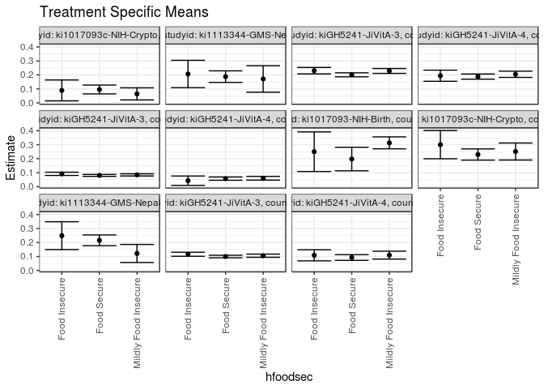

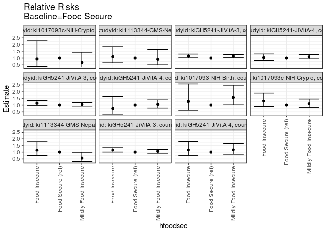

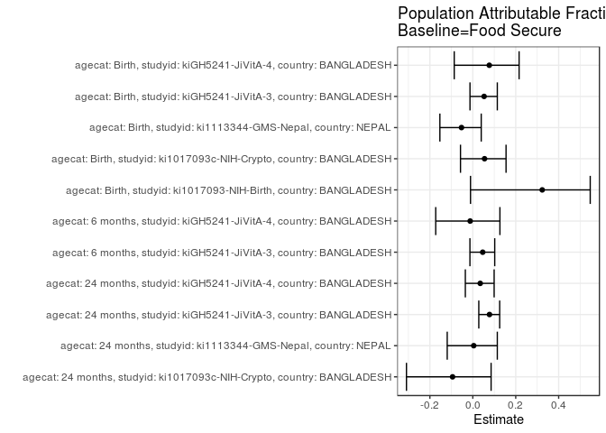

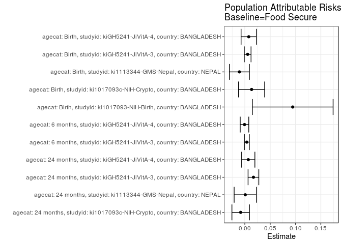

## Results Table

### Parameter: TSM

| agecat | studyid | country | intervention_level | baseline_level | estimate | ci_lower | ci_upper |
| --- | --- | --- | --- | --- | --- | --- | --- |
| Birth | ki1017093-NIH-Birth | BANGLADESH | Food Secure | NA | 0.1976744 | 0.1134327 | 0.2819162 |
| Birth | ki1017093-NIH-Birth | BANGLADESH | Mildly Food Insecure | NA | 0.3134658 | 0.2707092 | 0.3562224 |
| Birth | ki1017093-NIH-Birth | BANGLADESH | Food Insecure | NA | 0.2500000 | 0.1084286 | 0.3915714 |
| Birth | ki1017093c-NIH-Crypto | BANGLADESH | Food Secure | NA | 0.2299712 | 0.1900035 | 0.2699390 |
| Birth | ki1017093c-NIH-Crypto | BANGLADESH | Mildly Food Insecure | NA | 0.2514036 | 0.1905550 | 0.3122522 |
| Birth | ki1017093c-NIH-Crypto | BANGLADESH | Food Insecure | NA | 0.3005262 | 0.1995505 | 0.4015020 |
| Birth | ki1113344-GMS-Nepal | NEPAL | Food Secure | NA | 0.2156311 | 0.1770857 | 0.2541766 |
| Birth | ki1113344-GMS-Nepal | NEPAL | Mildly Food Insecure | NA | 0.1216186 | 0.0570911 | 0.1861461 |
| Birth | ki1113344-GMS-Nepal | NEPAL | Food Insecure | NA | 0.2488455 | 0.1491435 | 0.3485475 |
| Birth | kiGH5241-JiVitA-3 | BANGLADESH | Food Secure | NA | 0.0997026 | 0.0907417 | 0.1086636 |
| Birth | kiGH5241-JiVitA-3 | BANGLADESH | Mildly Food Insecure | NA | 0.1056574 | 0.0943043 | 0.1170105 |
| Birth | kiGH5241-JiVitA-3 | BANGLADESH | Food Insecure | NA | 0.1159523 | 0.1014870 | 0.1304176 |
| Birth | kiGH5241-JiVitA-4 | BANGLADESH | Food Secure | NA | 0.0925847 | 0.0721687 | 0.1130006 |
| Birth | kiGH5241-JiVitA-4 | BANGLADESH | Mildly Food Insecure | NA | 0.1095684 | 0.0815007 | 0.1376360 |
| Birth | kiGH5241-JiVitA-4 | BANGLADESH | Food Insecure | NA | 0.1084072 | 0.0685440 | 0.1482703 |
| 6 months | kiGH5241-JiVitA-3 | BANGLADESH | Food Secure | NA | 0.0807402 | 0.0738115 | 0.0876689 |
| 6 months | kiGH5241-JiVitA-3 | BANGLADESH | Mildly Food Insecure | NA | 0.0843844 | 0.0766625 | 0.0921063 |
| 6 months | kiGH5241-JiVitA-3 | BANGLADESH | Food Insecure | NA | 0.0919464 | 0.0803767 | 0.1035161 |
| 6 months | kiGH5241-JiVitA-4 | BANGLADESH | Food Secure | NA | 0.0576326 | 0.0459400 | 0.0693252 |
| 6 months | kiGH5241-JiVitA-4 | BANGLADESH | Mildly Food Insecure | NA | 0.0604940 | 0.0472037 | 0.0737843 |
| 6 months | kiGH5241-JiVitA-4 | BANGLADESH | Food Insecure | NA | 0.0430763 | 0.0096030 | 0.0765495 |
| 24 months | ki1017093c-NIH-Crypto | BANGLADESH | Food Secure | NA | 0.0958084 | 0.0642126 | 0.1274042 |
| 24 months | ki1017093c-NIH-Crypto | BANGLADESH | Mildly Food Insecure | NA | 0.0645161 | 0.0212336 | 0.1077986 |
| 24 months | ki1017093c-NIH-Crypto | BANGLADESH | Food Insecure | NA | 0.0892857 | 0.0145275 | 0.1640439 |
| 24 months | ki1113344-GMS-Nepal | NEPAL | Food Secure | NA | 0.1878725 | 0.1465355 | 0.2292095 |
| 24 months | ki1113344-GMS-Nepal | NEPAL | Mildly Food Insecure | NA | 0.1713543 | 0.0767536 | 0.2659551 |
| 24 months | ki1113344-GMS-Nepal | NEPAL | Food Insecure | NA | 0.2066205 | 0.1088765 | 0.3043646 |
| 24 months | kiGH5241-JiVitA-3 | BANGLADESH | Food Secure | NA | 0.2008734 | 0.1866899 | 0.2150569 |
| 24 months | kiGH5241-JiVitA-3 | BANGLADESH | Mildly Food Insecure | NA | 0.2284614 | 0.2109955 | 0.2459274 |
| 24 months | kiGH5241-JiVitA-3 | BANGLADESH | Food Insecure | NA | 0.2302491 | 0.2073233 | 0.2531749 |
| 24 months | kiGH5241-JiVitA-4 | BANGLADESH | Food Secure | NA | 0.1881009 | 0.1697429 | 0.2064588 |
| 24 months | kiGH5241-JiVitA-4 | BANGLADESH | Mildly Food Insecure | NA | 0.2046701 | 0.1824541 | 0.2268860 |
| 24 months | kiGH5241-JiVitA-4 | BANGLADESH | Food Insecure | NA | 0.1942667 | 0.1544466 | 0.2340869 |

### Parameter: E(Y)

| agecat | studyid | country | intervention_level | baseline_level | estimate | ci_lower | ci_upper |
| --- | --- | --- | --- | --- | --- | --- | --- |
| Birth | ki1017093-NIH-Birth | BANGLADESH | NA | NA | 0.2921739 | 0.2549711 | 0.3293768 |
| Birth | ki1017093c-NIH-Crypto | BANGLADESH | NA | NA | 0.2432815 | 0.2116319 | 0.2749310 |
| Birth | ki1113344-GMS-Nepal | NEPAL | NA | NA | 0.2048387 | 0.1730454 | 0.2366321 |
| Birth | kiGH5241-JiVitA-3 | BANGLADESH | NA | NA | 0.1052453 | 0.0993428 | 0.1111477 |
| Birth | kiGH5241-JiVitA-4 | BANGLADESH | NA | NA | 0.1002937 | 0.0848872 | 0.1157003 |
| 6 months | kiGH5241-JiVitA-3 | BANGLADESH | NA | NA | 0.0846457 | 0.0798459 | 0.0894454 |
| 6 months | kiGH5241-JiVitA-4 | BANGLADESH | NA | NA | 0.0569343 | 0.0480657 | 0.0658029 |
| 24 months | ki1017093c-NIH-Crypto | BANGLADESH | NA | NA | 0.0875486 | 0.0630907 | 0.1120065 |
| 24 months | ki1113344-GMS-Nepal | NEPAL | NA | NA | 0.1886792 | 0.1535311 | 0.2238274 |
| 24 months | kiGH5241-JiVitA-3 | BANGLADESH | NA | NA | 0.2178266 | 0.2079286 | 0.2277246 |
| 24 months | kiGH5241-JiVitA-4 | BANGLADESH | NA | NA | 0.1948467 | 0.1815077 | 0.2081857 |

### Parameter: RR

| agecat | studyid | country | intervention_level | baseline_level | estimate | ci_lower | ci_upper |
| --- | --- | --- | --- | --- | --- | --- | --- |
| Birth | ki1017093-NIH-Birth | BANGLADESH | Food Secure | Food Secure | 1.0000000 | 1.0000000 | 1.0000000 |
| Birth | ki1017093-NIH-Birth | BANGLADESH | Mildly Food Insecure | Food Secure | 1.5857681 | 1.0137016 | 2.4806713 |
| Birth | ki1017093-NIH-Birth | BANGLADESH | Food Insecure | Food Secure | 1.2647059 | 0.6225768 | 2.5691303 |
| Birth | ki1017093c-NIH-Crypto | BANGLADESH | Food Secure | Food Secure | 1.0000000 | 1.0000000 | 1.0000000 |
| Birth | ki1017093c-NIH-Crypto | BANGLADESH | Mildly Food Insecure | Food Secure | 1.0931956 | 0.8113624 | 1.4729260 |
| Birth | ki1017093c-NIH-Crypto | BANGLADESH | Food Insecure | Food Secure | 1.3067992 | 0.8953528 | 1.9073200 |
| Birth | ki1113344-GMS-Nepal | NEPAL | Food Secure | Food Secure | 1.0000000 | 1.0000000 | 1.0000000 |
| Birth | ki1113344-GMS-Nepal | NEPAL | Mildly Food Insecure | Food Secure | 0.5640122 | 0.3223282 | 0.9869125 |
| Birth | ki1113344-GMS-Nepal | NEPAL | Food Insecure | Food Secure | 1.1540333 | 0.7445825 | 1.7886438 |
| Birth | kiGH5241-JiVitA-3 | BANGLADESH | Food Secure | Food Secure | 1.0000000 | 1.0000000 | 1.0000000 |
| Birth | kiGH5241-JiVitA-3 | BANGLADESH | Mildly Food Insecure | Food Secure | 1.0597247 | 0.9173075 | 1.2242530 |
| Birth | kiGH5241-JiVitA-3 | BANGLADESH | Food Insecure | Food Secure | 1.1629809 | 1.0020507 | 1.3497567 |
| Birth | kiGH5241-JiVitA-4 | BANGLADESH | Food Secure | Food Secure | 1.0000000 | 1.0000000 | 1.0000000 |
| Birth | kiGH5241-JiVitA-4 | BANGLADESH | Mildly Food Insecure | Food Secure | 1.1834398 | 0.8463715 | 1.6547461 |
| Birth | kiGH5241-JiVitA-4 | BANGLADESH | Food Insecure | Food Secure | 1.1708976 | 0.7605613 | 1.8026178 |
| 6 months | kiGH5241-JiVitA-3 | BANGLADESH | Food Secure | Food Secure | 1.0000000 | 1.0000000 | 1.0000000 |
| 6 months | kiGH5241-JiVitA-3 | BANGLADESH | Mildly Food Insecure | Food Secure | 1.0451348 | 0.9230470 | 1.1833707 |
| 6 months | kiGH5241-JiVitA-3 | BANGLADESH | Food Insecure | Food Secure | 1.1387932 | 0.9807774 | 1.3222674 |
| 6 months | kiGH5241-JiVitA-4 | BANGLADESH | Food Secure | Food Secure | 1.0000000 | 1.0000000 | 1.0000000 |
| 6 months | kiGH5241-JiVitA-4 | BANGLADESH | Mildly Food Insecure | Food Secure | 1.0496494 | 0.7796049 | 1.4132335 |
| 6 months | kiGH5241-JiVitA-4 | BANGLADESH | Food Insecure | Food Secure | 0.7474288 | 0.3372396 | 1.6565371 |
| 24 months | ki1017093c-NIH-Crypto | BANGLADESH | Food Secure | Food Secure | 1.0000000 | 1.0000000 | 1.0000000 |
| 24 months | ki1017093c-NIH-Crypto | BANGLADESH | Mildly Food Insecure | Food Secure | 0.6733871 | 0.3188651 | 1.4220753 |
| 24 months | ki1017093c-NIH-Crypto | BANGLADESH | Food Insecure | Food Secure | 0.9319196 | 0.3789294 | 2.2919156 |
| 24 months | ki1113344-GMS-Nepal | NEPAL | Food Secure | Food Secure | 1.0000000 | 1.0000000 | 1.0000000 |
| 24 months | ki1113344-GMS-Nepal | NEPAL | Mildly Food Insecure | Food Secure | 0.9120779 | 0.5033388 | 1.6527356 |
| 24 months | ki1113344-GMS-Nepal | NEPAL | Food Insecure | Food Secure | 1.0997912 | 0.6523453 | 1.8541416 |
| 24 months | kiGH5241-JiVitA-3 | BANGLADESH | Food Secure | Food Secure | 1.0000000 | 1.0000000 | 1.0000000 |
| 24 months | kiGH5241-JiVitA-3 | BANGLADESH | Mildly Food Insecure | Food Secure | 1.1373405 | 1.0250801 | 1.2618949 |
| 24 months | kiGH5241-JiVitA-3 | BANGLADESH | Food Insecure | Food Secure | 1.1462398 | 1.0181261 | 1.2904744 |
| 24 months | kiGH5241-JiVitA-4 | BANGLADESH | Food Secure | Food Secure | 1.0000000 | 1.0000000 | 1.0000000 |
| 24 months | kiGH5241-JiVitA-4 | BANGLADESH | Mildly Food Insecure | Food Secure | 1.0880867 | 0.9411121 | 1.2580144 |
| 24 months | kiGH5241-JiVitA-4 | BANGLADESH | Food Insecure | Food Secure | 1.0327795 | 0.8225491 | 1.2967413 |

### Parameter: PAR

| agecat | studyid | country | intervention_level | baseline_level | estimate | ci_lower | ci_upper |
| --- | --- | --- | --- | --- | --- | --- | --- |
| Birth | ki1017093-NIH-Birth | BANGLADESH | Food Secure | NA | 0.0944995 | 0.0147631 | 0.1742359 |
| Birth | ki1017093c-NIH-Crypto | BANGLADESH | Food Secure | NA | 0.0133102 | -0.0124718 | 0.0390923 |
| Birth | ki1113344-GMS-Nepal | NEPAL | Food Secure | NA | -0.0107924 | -0.0305400 | 0.0089552 |
| Birth | kiGH5241-JiVitA-3 | BANGLADESH | Food Secure | NA | 0.0055426 | -0.0011407 | 0.0122259 |
| Birth | kiGH5241-JiVitA-4 | BANGLADESH | Food Secure | NA | 0.0077091 | -0.0074636 | 0.0228818 |
| 6 months | kiGH5241-JiVitA-3 | BANGLADESH | Food Secure | NA | 0.0039055 | -0.0009721 | 0.0087830 |
| 6 months | kiGH5241-JiVitA-4 | BANGLADESH | Food Secure | NA | -0.0006983 | -0.0091701 | 0.0077736 |
| 24 months | ki1017093c-NIH-Crypto | BANGLADESH | Food Secure | NA | -0.0082597 | -0.0255539 | 0.0090344 |
| 24 months | ki1113344-GMS-Nepal | NEPAL | Food Secure | NA | 0.0008067 | -0.0211645 | 0.0227779 |
| 24 months | kiGH5241-JiVitA-3 | BANGLADESH | Food Secure | NA | 0.0169532 | 0.0063629 | 0.0275436 |
| 24 months | kiGH5241-JiVitA-4 | BANGLADESH | Food Secure | NA | 0.0067458 | -0.0063256 | 0.0198172 |

### Parameter: PAF

| agecat | studyid | country | intervention_level | baseline_level | estimate | ci_lower | ci_upper |
| --- | --- | --- | --- | --- | --- | --- | --- |
| Birth | ki1017093-NIH-Birth | BANGLADESH | Food Secure | NA | 0.3234358 | -0.0106683 | 0.5470926 |
| Birth | ki1017093c-NIH-Crypto | BANGLADESH | Food Secure | NA | 0.0547112 | -0.0573647 | 0.1549076 |
| Birth | ki1113344-GMS-Nepal | NEPAL | Food Secure | NA | -0.0526874 | -0.1534188 | 0.0392468 |
| Birth | kiGH5241-JiVitA-3 | BANGLADESH | Food Secure | NA | 0.0526638 | -0.0131203 | 0.1141764 |
| Birth | kiGH5241-JiVitA-4 | BANGLADESH | Food Secure | NA | 0.0768651 | -0.0865496 | 0.2157025 |
| 6 months | kiGH5241-JiVitA-3 | BANGLADESH | Food Secure | NA | 0.0461389 | -0.0133928 | 0.1021734 |
| 6 months | kiGH5241-JiVitA-4 | BANGLADESH | Food Secure | NA | -0.0122648 | -0.1727738 | 0.1262765 |
| 24 months | ki1017093c-NIH-Crypto | BANGLADESH | Food Secure | NA | -0.0943446 | -0.3091652 | 0.0852260 |
| 24 months | ki1113344-GMS-Nepal | NEPAL | Food Secure | NA | 0.0042758 | -0.1192517 | 0.1141700 |
| 24 months | kiGH5241-JiVitA-3 | BANGLADESH | Food Secure | NA | 0.0778290 | 0.0279300 | 0.1251665 |
| 24 months | kiGH5241-JiVitA-4 | BANGLADESH | Food Secure | NA | 0.0346210 | -0.0348094 | 0.0993930 |